# ETC3250/5250 IML Asignment 3 Solution

### Question 4

Show what aspect of the data the first and second principal component loadings capture like the example plot below. (2 marks)

[figure not shown]

```r
#INCLUDE YOUR R CODE HERE
set.seed(2023)
Xnew_pca1 <- mydata_pca$x[, 1] %*% t(mydata_pca$rotation[, 1])
Pdata_pca1 <- as.data.frame(Xnew_pca1)
plot_function(Pdata_pca1, 1, 1)
```

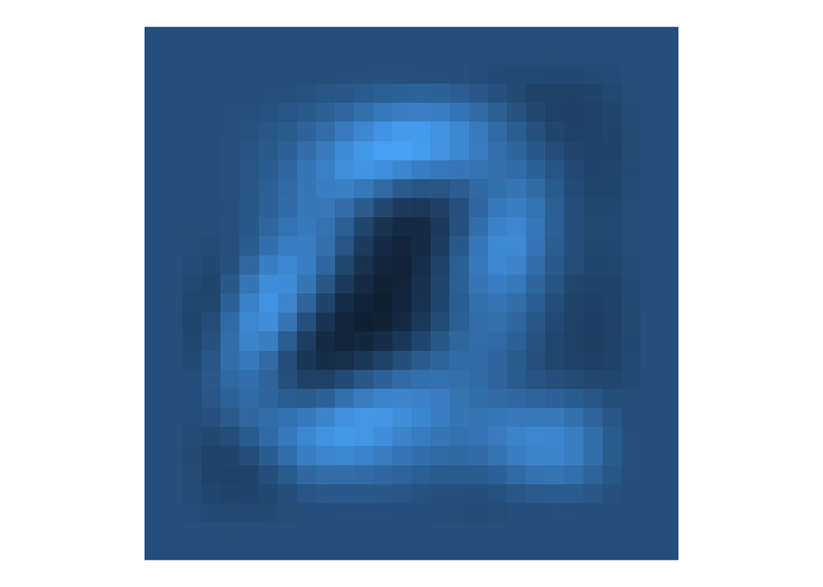

```r
Xnew_pca2 <- mydata_pca$x[, 2] %*% t(mydata_pca$rotation[, 2])
Pdata_pca2 <- as.data.frame(Xnew_pca2)
plot_function(Pdata_pca2, 1, 1)
```

[output not shown]

### Question 5

Using the rotated data from the PCA, perform an agglomeration hierarchical clustering with average linkage. (2 marks)

```r
#INCLUDE YOUR R CODE HERE
haverage <- hclust(dist(mydata_pca$x), method = "average")
```

### Question 6

Cut the tree from question 5 to 4 clusters. Show how many observations you have per cluster. (2 marks)

```r
#INCLUDE YOUR R CODE HERE
caverage <- cutree(haverage, k = 4)
table(caverage)
```

```
## caverage
##    1    2    3    4
## 3376   13    1    1
```

The output shows that the first cluster contains 3376 observations, the second cluster contains 13 observations, and the third and the fourth clusters each contain only one observation.

### Question 7

Show a sample of 10 (or the total number of images in a cluster if less than 10 observations in a cluster) images from each cluster like the plot below. What do you notice about the cluster groups? (3 marks)

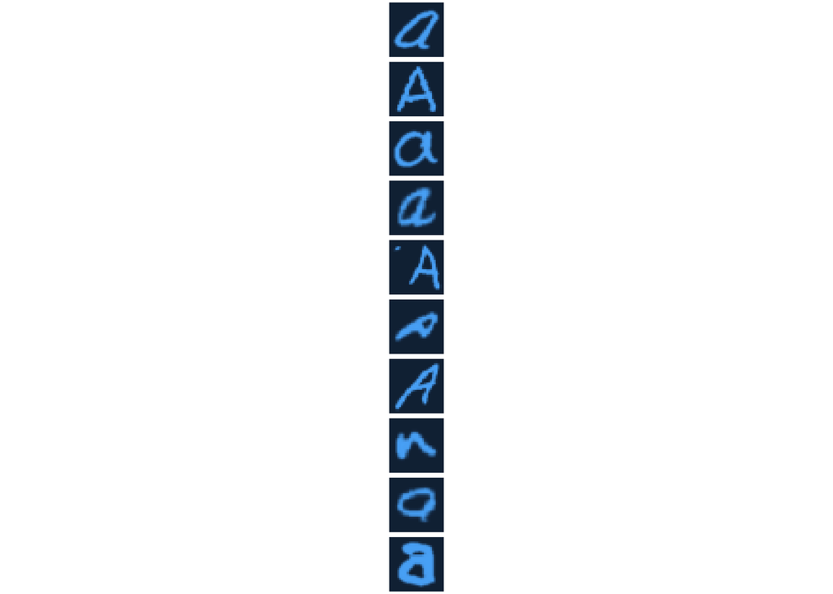

```r
#INCLUDE YOUR R CODE HERE
set.seed(2023)
cluster1_data <- mydata[caverage == 1, ]
plot1 <- plot_function(cluster1_data, 10, 1)
```

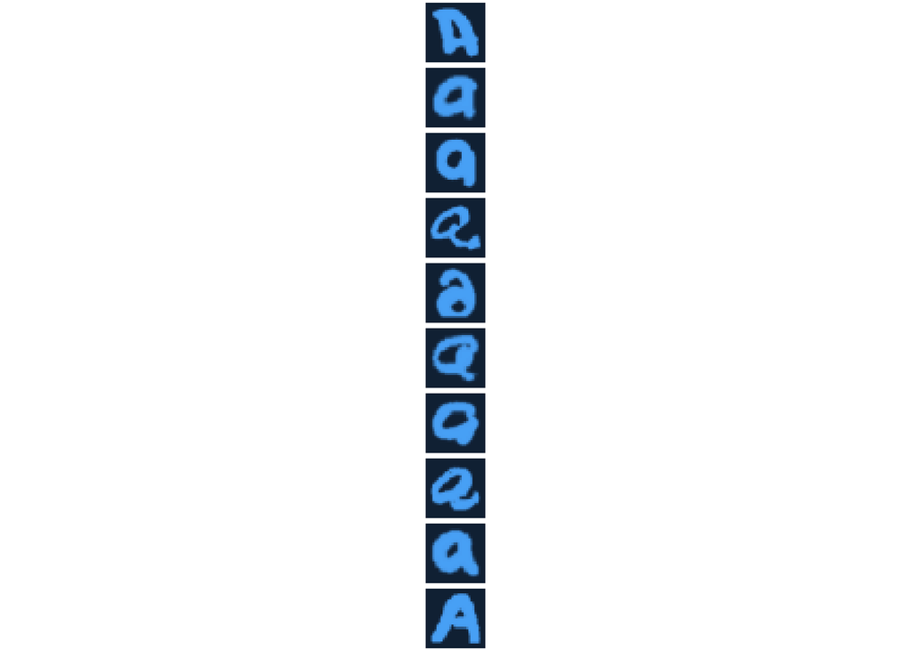

```r
cluster2_data <- mydata[caverage == 2, ]
plot2 <- plot_function(cluster2_data, 10, 1)
```

[figure not shown]

```r
cluster3_data <- mydata[caverage == 3, ]
plot3 <-plot_function(cluster3_data, 1, 1)
```